# Final Project

Ashkan Dastani & Damilare Olaleye

12/5/2019

## Introduction

This is data from Pronto, which is Seattle’s cycle sharing system with 500 bikes and 50 stations located throughout the city. This is data on all 2015 trips.

Some notes about the data are trips of duration less than one minute or greater than eight hours were removed from original table and

Gender and birth year are only available for Annual Members.

-starttime: day and time trip started, in PST

-stoptime: day and time trip ended, in PST

-tripduration: time of trip in seconds

-from_station_name: name of station where trip originated

-to_station_name: name of station where trip terminated

-usertype: “Short-Term Pass Holder” is a rider who purchased a 24-Hour or 3-Day Pass; “Annual Member” is a rider who purchased an Annual Membership

-gender: gender of rider

-birthyear: birth year of rider

-bikeid: ID attached to each bike

-trip_id: numeric ID of bike triptrip taken

-from_station_id: ID of station where trip originated

-to_station_id: ID of station where trip terminated

## Questions

1. How long are typical bike trips?
2. What ages and gender are taking bike trips?
3. What are popular stations to depart and arrive?
4. What days and times are popular for taking bike trips?

## R Markdown

```r
library(tidyverse)
ds <- read_csv("http://personal.bgsu.edu/~dashkan/trip.csv")
ds %>% mutate(age = 2015 - birthyear) ->ds
ds %>% filter(trip_id != 59000) -> ds
ds
```

```
## # A tibble: 92,281 x 13
##    trip_id starttime stoptime bikeid tripduration from_station_na…
##      <dbl> <chr>     <chr>    <chr>         <dbl> <chr>
##  1     431 10/13/20… 10/13/2… SEA00…         986. 2nd Ave & Sprin…
##  2     432 10/13/20… 10/13/2… SEA00…         926. 2nd Ave & Sprin…
##  3     433 10/13/20… 10/13/2… SEA00…         884. 2nd Ave & Sprin…
##  4     434 10/13/20… 10/13/2… SEA00…         866. 2nd Ave & Sprin…
##  5     435 10/13/20… 10/13/2… SEA00…         924. 2nd Ave & Sprin…
##  6     436 10/13/20… 10/13/2… SEA00…         809. 2nd Ave & Sprin…
##  7     437 10/13/20… 10/13/2… SEA00…         597. Occidental Park…
##  8     438 10/13/20… 10/13/2… SEA00…         592. Occidental Park…
##  9     439 10/13/20… 10/13/2… SEA00…         586. Occidental Park…
## 10     440 10/13/20… 10/13/2… SEA00…         588. Occidental Park…
## # … with 92,271 more rows, and 7 more variables: to_station_name <chr>,
## #   from_station_id <chr>, to_station_id <chr>, usertype <chr>,
## #   gender <chr>, birthyear <dbl>, age <dbl>
```

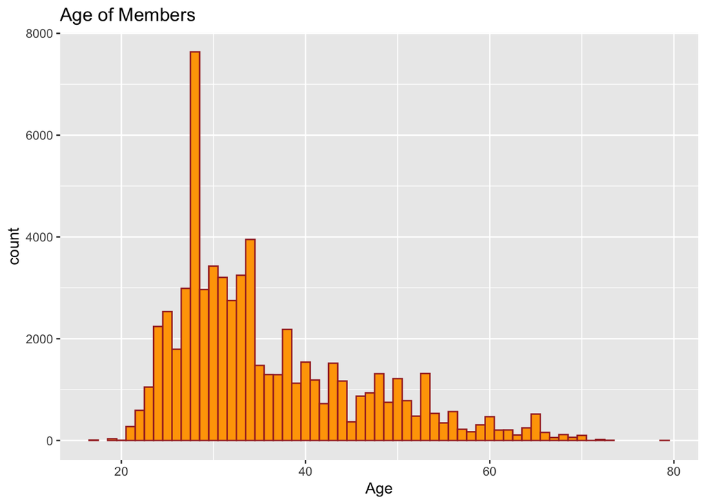

```r
ggplot(ds, aes(age)) + geom_bar(width = 1, color = "brown", fill = "orange") + ggtitle("Age of Members") + xlab("Age")
```

From the graph we can see that the count of most users are between the ages of 20 and 40. We can also see that there is a large spike just before the 30 year old mark. There are very few members in the higher age ranges. And finally, there are also almost no under 20 year old users.

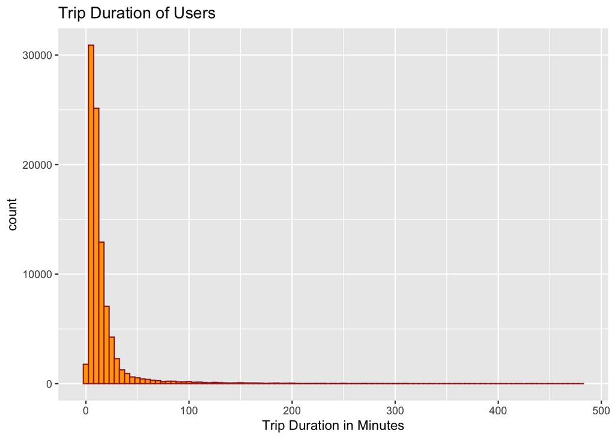

```r
ds %>% mutate(tripinmin = tripduration/60) -> ds2
ggplot(ds2, aes(tripinmin)) + geom_histogram(color = "brown", fill = "orange", binwidth = 5) + xlab("Trip Duration in Minutes") + ggtitle("Trip Duration of Users")
```

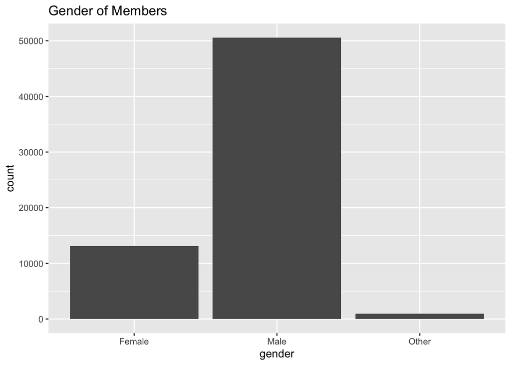

```r
ds2 %>% filter(!is.na(gender)) -> ds3
ggplot(ds3, aes(gender)) + geom_bar() + ggtitle("Gender of Members")
```

The graph shows that the vast majority of users are Male. The combination of the femail and other category do not even come close to the number of male riders.

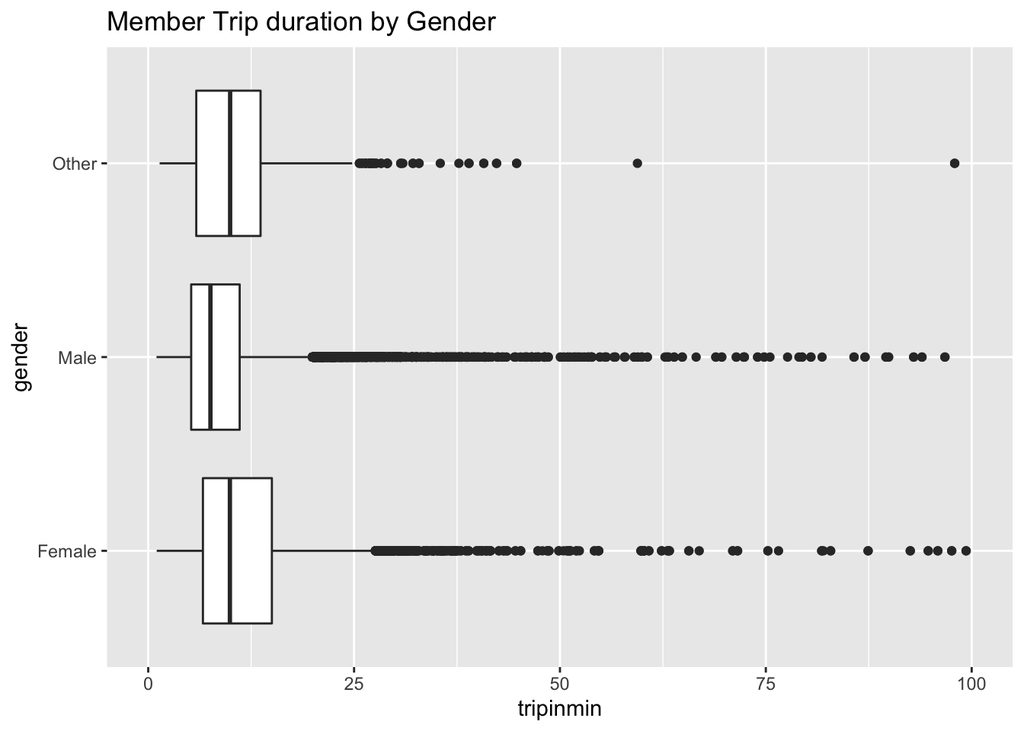

```r
ggplot(ds3, aes(gender, tripinmin)) + geom_boxplot() + coord_flip() + ylim(0,100) + ggtitle("Member Trip duration by Gender")
```

The graph shows that the female and other categories on average takes longer trips than male, the graph graph shows a very large number of outliers

```r
ds2 %>% group_by(age) %>%
  summarize(N = n(), avgtripinmin = mean(tripinmin)) %>%  arrange(desc(N)) -> avgtripbyage
avgtripbyage
```

```
## # A tibble: 58 x 3
##      age     N avgtripinmin
##    <dbl> <int>        <dbl>
##  1    NA 27632        35.1
##  2    28  7636         9.15
##  3    34  3950        10.1
##  4    30  3427        10.0
##  5    33  3247        10.4
##  6    31  3205        11.0
##  7    27  2989        10.6
##  8    29  2966        10.6
##  9    32  2750         9.48
## 10    25  2533         8.55
## # … with 48 more rows
```

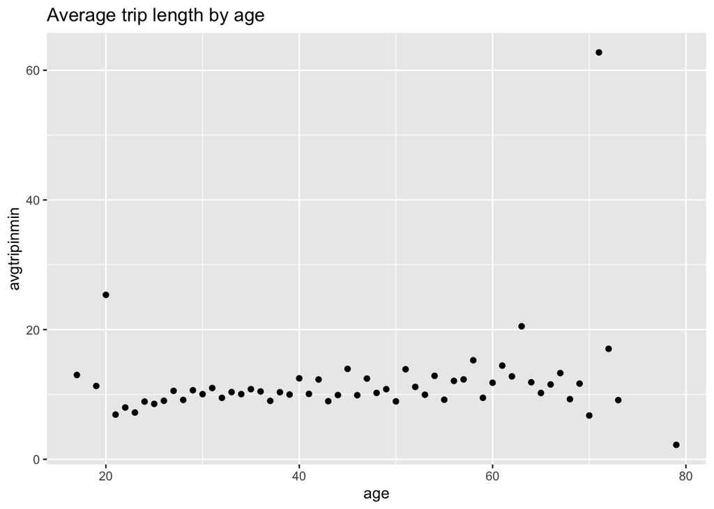

```r
ggplot(avgtripbyage, aes(age, avgtripinmin)) + geom_point() + ggtitle("Average trip length by age")
```

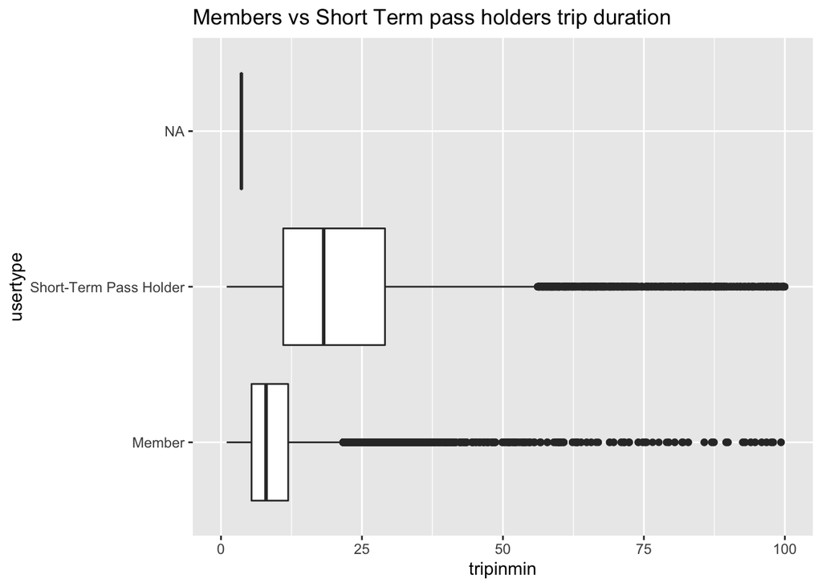

```r
ggplot(ds2, aes(usertype, tripinmin)) + geom_boxplot() + coord_flip() + ylim(0,100) + ggtitle("Members vs Short Term pass holders trip duration")
```

The short-term pass holders on average had the longer trips compared to the members. There are large number of outliers from the groups, but the members have more outliers than the short-term pass holder.

```r
ds %>% group_by(from_station_name) %>%
  summarize(N = n()) %>%  arrange(desc(N)) ->popfromstations
popfromstations
```

```
## # A tibble: 51 x 2
##    from_station_name                          N
##    <chr>                                  <int>
##  1 REI / Yale Ave N & John St              3631
##  2 E Harrison St & Broadway Ave E          3570
##  3 E Pine St & 16th Ave                    3504
##  4 2nd Ave & Pine St                       3366
##  5 Westlake Ave & 6th Ave                  3281
##  6 Cal Anderson Park / 11th Ave & Pine St  3211
##  7 Pier 69 / Alaskan Way & Clay St         3108
##  8 2nd Ave & Vine St                       2924
##  9 PATH / 9th Ave & Westlake Ave           2900
## 10 3rd Ave & Broad St                      2703
## # … with 41 more rows
```

```r
head(popfromstations)
```

```
## # A tibble: 6 x 2
##   from_station_name                          N
##   <chr>                                  <int>
## 1 REI / Yale Ave N & John St              3631
## 2 E Harrison St & Broadway Ave E          3570
## 3 E Pine St & 16th Ave                    3504
## 4 2nd Ave & Pine St                       3366
## 5 Westlake Ave & 6th Ave                  3281
## 6 Cal Anderson Park / 11th Ave & Pine St  3211
```

```r
head(popfromstations %>% arrange(N))
```

```
## # A tibble: 6 x 2
##   from_station_name                                                       N
##   <chr>                                                               <int>
## 1 E Harrison St & Br                                                      1
## 2 UW Magnuson Health Sciences Center Rotunda / Columbia Rd & San Jua…   441
## 3 UW McCarty Hall / Whitman Ct                                          495
## 4 NE 42nd St & University Way NE                                        541
## 5 UW Intramural Activities Building                                     550
## 6 Burke Museum / E Stevens Way NE & Memorial Way NE                     672
```

```r
ds %>% group_by(to_station_name) %>%
  summarize(N = n()) %>%  arrange(desc(N)) -> poptostations
poptostations
```

```
## # A tibble: 52 x 2
##    to_station_name                                          N
##    <chr>                                                <int>
##  1 2nd Ave & Pine St                                     4342
##  2 PATH / 9th Ave & Westlake Ave                         3926
##  3 REI / Yale Ave N & John St                            3899
##  4 7th Ave & Union St                                    3677
##  5 Westlake Ave & 6th Ave                                3567
##  6 Pier 69 / Alaskan Way & Clay St                       3483
##  7 Republican St & Westlake Ave N                        3240
##  8 Occidental Park / Occidental Ave S & S Washington St  3101
##  9 Pine St & 9th Ave                                     3089
## 10 2nd Ave & Spring St                                   3027
## # … with 42 more rows
```

```r
head(poptostations)
```

```
## # A tibble: 6 x 2
##   to_station_name                     N
##   <chr>                           <int>
## 1 2nd Ave & Pine St                4342
## 2 PATH / 9th Ave & Westlake Ave    3926
## 3 REI / Yale Ave N & John St       3899
## 4 7th Ave & Union St               3677
## 5 Westlake Ave & 6th Ave           3567
## 6 Pier 69 / Alaskan Way & Clay St  3483
```

```r
head(poptostations %>% arrange(N))
```

```
## # A tibble: 6 x 2
##   to_station_name                                       N
##   <chr>                                             <int>
## 1 <NA>                                                  1
## 2 Pronto shop                                           6
## 3 UW McCarty Hall / Whitman Ct                        366
## 4 Burke Museum / E Stevens Way NE & Memorial Way NE   445
## 5 12th Ave & E Denny Way                              524
## 6 NE 47th St & 12th Ave NE                            579
```

```r
ds %>% mutate(timeofdaystarted = starttime) -> ds4
ds4 %>% mutate(timeofdaystarted = substr(timeofdaystarted, 11, 16)) -> ds4
ds4 %>% mutate(timeofdaystopped = stoptime) ->ds4
ds4 %>% mutate(timeofdaystopped = substr(timeofdaystopped, 11, 16)) -> ds4
ds4
```

```
## # A tibble: 92,281 x 15
##    trip_id starttime stoptime bikeid tripduration from_station_na…
##      <dbl> <chr>     <chr>    <chr>         <dbl> <chr>
##  1     431 10/13/20… 10/13/2… SEA00…         986. 2nd Ave & Sprin…
##  2     432 10/13/20… 10/13/2… SEA00…         926. 2nd Ave & Sprin…
##  3     433 10/13/20… 10/13/2… SEA00…         884. 2nd Ave & Sprin…
##  4     434 10/13/20… 10/13/2… SEA00…         866. 2nd Ave & Sprin…
##  5     435 10/13/20… 10/13/2… SEA00…         924. 2nd Ave & Sprin…
##  6     436 10/13/20… 10/13/2… SEA00…         809. 2nd Ave & Sprin…
##  7     437 10/13/20… 10/13/2… SEA00…         597. Occidental Park…
##  8     438 10/13/20… 10/13/2… SEA00…         592. Occidental Park…
##  9     439 10/13/20… 10/13/2… SEA00…         586. Occidental Park…
## 10     440 10/13/20… 10/13/2… SEA00…         588. Occidental Park…
## # … with 92,271 more rows, and 9 more variables: to_station_name <chr>,
## #   from_station_id <chr>, to_station_id <chr>, usertype <chr>,
## #   gender <chr>, birthyear <dbl>, age <dbl>, timeofdaystarted <chr>,
## #   timeofdaystopped <chr>
```

```r
library(lubridate)
ds4 %>% mutate(timeofdaystarted = ((as.numeric(seconds(hm(timeofdaystarted))))/60)/60) -> ds5
ds5
```

```
## # A tibble: 92,281 x 15
##    trip_id starttime stoptime bikeid tripduration from_station_na…
##      <dbl> <chr>     <chr>    <chr>         <dbl> <chr>
##  1     431 10/13/20… 10/13/2… SEA00…         986. 2nd Ave & Sprin…
##  2     432 10/13/20… 10/13/2… SEA00…         926. 2nd Ave & Sprin…
##  3     433 10/13/20… 10/13/2… SEA00…         884. 2nd Ave & Sprin…
##  4     434 10/13/20… 10/13/2… SEA00…         866. 2nd Ave & Sprin…
##  5     435 10/13/20… 10/13/2… SEA00…         924. 2nd Ave & Sprin…
##  6     436 10/13/20… 10/13/2… SEA00…         809. 2nd Ave & Sprin…
##  7     437 10/13/20… 10/13/2… SEA00…         597. Occidental Park…
##  8     438 10/13/20… 10/13/2… SEA00…         592. Occidental Park…
##  9     439 10/13/20… 10/13/2… SEA00…         586. Occidental Park…
## 10     440 10/13/20… 10/13/2… SEA00…         588. Occidental Park…
## # … with 92,271 more rows, and 9 more variables: to_station_name <chr>,
## #   from_station_id <chr>, to_station_id <chr>, usertype <chr>,
## #   gender <chr>, birthyear <dbl>, age <dbl>, timeofdaystarted <dbl>,
## #   timeofdaystopped <chr>
```

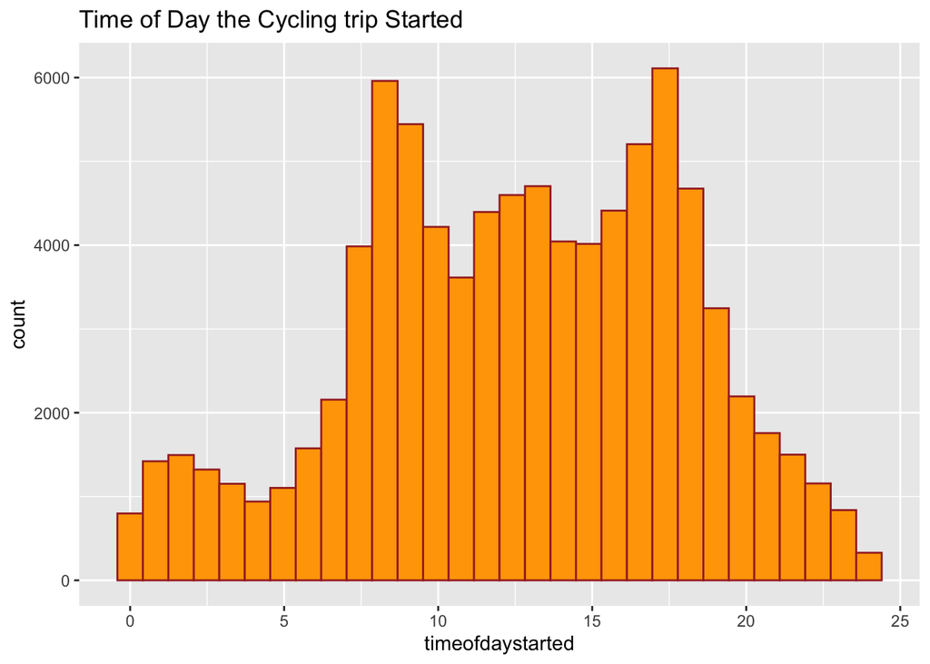

```r
ggplot(ds5, aes(timeofdaystarted)) + geom_histogram(color = "brown", fill = "orange") + ggtitle("Time of Day the Cycling trip Started")
```

```r
ds5 %>% mutate(timeofdaystopped = ((as.numeric(seconds(hm(timeofdaystopped))))/60)/60) -> ds5
ds5
```

```
## # A tibble: 92,281 x 15
##    trip_id starttime stoptime bikeid tripduration from_station_na…
##      <dbl> <chr>     <chr>    <chr>         <dbl> <chr>
##  1     431 10/13/20… 10/13/2… SEA00…         986. 2nd Ave & Sprin…
##  2     432 10/13/20… 10/13/2… SEA00…         926. 2nd Ave & Sprin…
##  3     433 10/13/20… 10/13/2… SEA00…         884. 2nd Ave & Sprin…
##  4     434 10/13/20… 10/13/2… SEA00…         866. 2nd Ave & Sprin…
##  5     435 10/13/20… 10/13/2… SEA00…         924. 2nd Ave & Sprin…
##  6     436 10/13/20… 10/13/2… SEA00…         809. 2nd Ave & Sprin…
##  7     437 10/13/20… 10/13/2… SEA00…         597. Occidental Park…
##  8     438 10/13/20… 10/13/2… SEA00…         592. Occidental Park…
##  9     439 10/13/20… 10/13/2… SEA00…         586. Occidental Park…
## 10     440 10/13/20… 10/13/2… SEA00…         588. Occidental Park…
## # … with 92,271 more rows, and 9 more variables: to_station_name <chr>,
## #   from_station_id <chr>, to_station_id <chr>, usertype <chr>,
## #   gender <chr>, birthyear <dbl>, age <dbl>, timeofdaystarted <dbl>,
## #   timeofdaystopped <dbl>
```

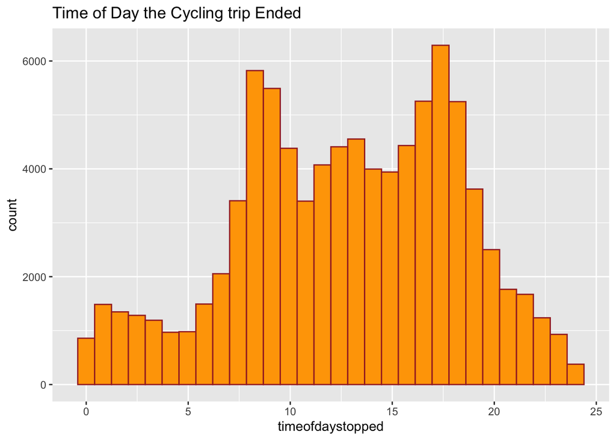

```r
ggplot(ds5, aes(timeofdaystopped)) + geom_histogram(color = "brown", fill = "orange") + ggtitle("Time of Day the Cycling trip Ended")
```

Since most trips are very short the this graph looks very similar to the time of day that trips started. For similar reasons.

```r
ds5 %>% mutate(dayofweek = starttime) -> ds5
ds5 %>% mutate(dayofweek = substr(dayofweek, 0, 10)) -> ds5
ds5 %>% mutate(dayofweek = wday(mdy(dayofweek), label = TRUE)) -> ds5
ds5
```

```
## # A tibble: 92,281 x 16
##    trip_id starttime stoptime bikeid tripduration from_station_na…
##      <dbl> <chr>     <chr>    <chr>         <dbl> <chr>
##  1     431 10/13/20… 10/13/2… SEA00…         986. 2nd Ave & Sprin…
##  2     432 10/13/20… 10/13/2… SEA00…         926. 2nd Ave & Sprin…
##  3     433 10/13/20… 10/13/2… SEA00…         884. 2nd Ave & Sprin…
##  4     434 10/13/20… 10/13/2… SEA00…         866. 2nd Ave & Sprin…
##  5     435 10/13/20… 10/13/2… SEA00…         924. 2nd Ave & Sprin…
##  6     436 10/13/20… 10/13/2… SEA00…         809. 2nd Ave & Sprin…
##  7     437 10/13/20… 10/13/2… SEA00…         597. Occidental Park…
##  8     438 10/13/20… 10/13/2… SEA00…         592. Occidental Park…
##  9     439 10/13/20… 10/13/2… SEA00…         586. Occidental Park…
## 10     440 10/13/20… 10/13/2… SEA00…         588. Occidental Park…
## # … with 92,271 more rows, and 10 more variables: to_station_name <chr>,
## #   from_station_id <chr>, to_station_id <chr>, usertype <chr>,
## #   gender <chr>, birthyear <dbl>, age <dbl>, timeofdaystarted <dbl>,
## #   timeofdaystopped <dbl>, dayofweek <ord>
```

```r
ds5 %>% filter(!is.na(dayofweek)) -> ds6
```

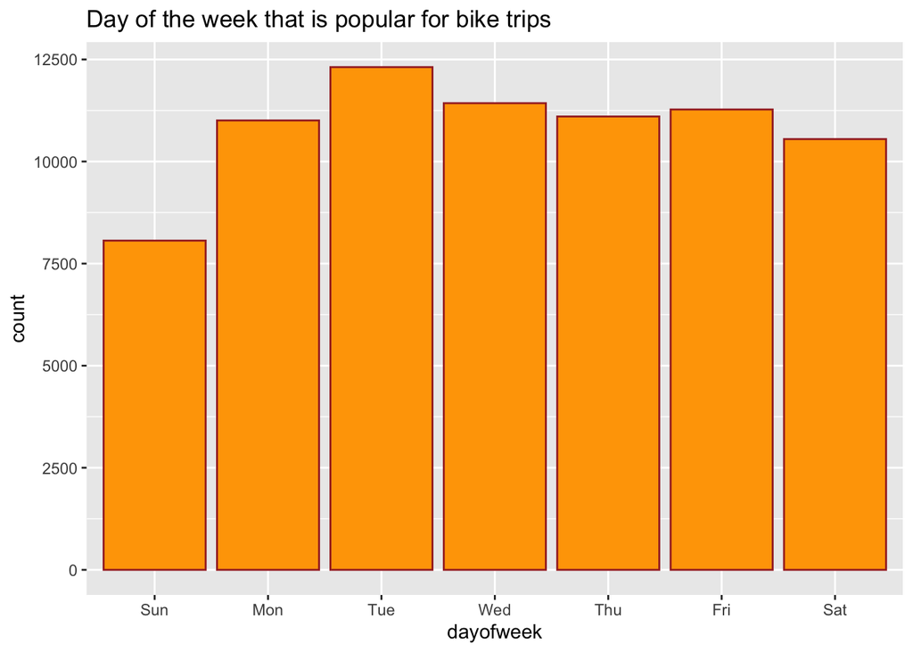

```r
ggplot(ds6, aes(dayofweek)) + geom_bar(color = "brown", fill = "orange") + ggtitle("Day of the week that is popular for bike trips")
```

From the graph we can see that the least popular day to use the bike sharing is on Sunday, while Saturday is the second least popular day for a trip. All of the week days are fairly similar to each other but Tuesday is the day of the week that is popular for bike trips.